# Swiftの環境構築

Swift言語でのiOSアプリ開発は、Apple公式の統合開発環境であるXcodeを用いるのが基本である。

## Xcodeとは

[figure not shown]

[Xcode](https://developer.apple.com/jp/xcode/)は、Appleが無料で提供している公式の統合開発環境（IDE）である。iOS、macOS、watchOS、tvOS向けのアプリケーションや、Swiftを用いた開発において標準的に使用される。

Xcodeには、単なるコードエディタだけでなく、以下のような開発に必要なすべての機能が組み込まれている。

- **コンパイラ・デバッガ**: 書いたプログラムを実際に動くアプリに変換したり、エラー（バグ）を見つけて直したりするための機能。
- **Interface Builder・SwiftUI Previews**: ボタンやテキストなどの画面デザインを、プレビューを見ながら直感的に作れる機能。
- **Simulator（シミュレータ）**: 手元に本物のiPhoneやiPadがなくても、Macの画面上に仮想のiPhoneを映してアプリをテストできる機能。
- **Instruments**: アプリの動作が重くないか、メモリを使いすぎていないかをチェックする分析ツール。

Xcodeの画面。Apple Newsroomより引用

[figure not shown]

iOSアプリ開発を含む、本格的なAppleプラットフォーム向け開発を行う場合、基本的にXcodeのインストールが必須である。

## Xcodeのインストール

公式の方法を用いたXcodeのインストールには、2つの方法がある。

▼ タブのタイトルをクリックして内容を切り替え

**App Storeから**

Xcodeの最新版は、通常のアプリケーション同様に、App Store（WindowsでいうMicrosoft Store）からインストールすることができる。

[Xcode - App Store](https://apps.apple.com/jp/app/xcode/id497799835)

[figure not shown]

しかし、App Store版のXcodeはAppleシリコン版しか配信されておらず、私のMacbookのようにIntelプロセッサで動くMacは別の方法でインストールする必要がある[^1]。

以前ユニバーサル版（Intelプロセッサ対応のもの）は個人的にApp Storeからインストールしており、Xcodeもバージョン26.3のものが入っていたのだが、最新版は26.6[^2]であるため、別の方法でアップデート（インストール）した。

**Apple Developerサイトから**

[Apple Developerサイト](https://developer.apple.com/download/applications/)では、Appleシリコン版だけでなくユニバーサル版もダウンロード可能である。

[figure not shown]

上の画像のように、赤枠の「Xcode 26.6 Universal >」の部分をクリックすると、`Xcode_26.6_Universal.xip`というファイルがダウンロードされる。

インストールされたら開き、ファイルを展開する[^3]と、`Xcode.app`が生成される。

展開後の`Xcode.app`

[figure not shown]

この`Xcode.app`をアプリケーションフォルダ（`/Applications`）に移動すると、インストールが完了する。

### 「Xcodes」によるバージョン管理

[figure not shown]

Apple Developerサイトから手動でインストールする方法は、アップデートのたびにサイトを開いてファイルをダウンロードする必要があり、少々手間がかかる。一方でApp Store版は、常に最新の1バージョンしか手元に残せないという欠点がある。実際の開発現場では、プロジェクトの要件やチーム内でのバージョン統一、あるいは古いiOSでの動作検証などの理由で、過去の特定バージョンやベータ版を複数使い分けたいケースが多々発生する。こうした不便さを解消し、複数バージョンのXcodeを簡単に管理できるのが**「Xcodes」**というツールである。

**重要**

Xcodesは**非公式ツール**であるため、利用にはリスクを伴うことに留意する。

- **セキュリティ上の懸念**: Xcodesはファイルのダウンロードや展開を自動で行うが、過去にはその仕組みの隙を突かれ、不正なファイルのダウンロードやデータの改ざんを許してしまう脆弱性が指摘されたことがある。また、そもそも非公式の経路からXcodeを入手すること自体にリスクがある。Xcodesでの事例ではないが、2015年には非公式のクラウドストレージからダウンロードしたXcodeに悪意のあるコードが仕込まれており、それを使ってビルドされたWeChatなどの有名アプリにマルウェアが混入する深刻な事件も起きている[^4]。
- **アカウント情報の漏洩**: XcodesはユーザーのApple Accountのログイン情報を保存し、Appleのサーバーと認証を行う。万が一ツール自体に脆弱性や悪意のあるコードが含まれていた場合、アカウント情報が漏洩するリスクが存在する。
- **Apple Developerアカウント利用規約の抵触**: そもそも非公式の管理アプリを使用することで、Apple Developer Programの規約に抵触し、アカウントが停止（垢BAN）される可能性がある。

### Xcodeのセットアップ

`Xcode.app`を開くと、最初にXcodeの利用に関する「[Xcode and Apple SDKs Agreement](https://www.apple.com/legal/sla/docs/xcode.pdf)」のライセンス契約内容が表示されるので、「Agree」を押して同意する。

[figure not shown]

その後、インストールの許可画面が表示されるので、Touch IDで管理者認証をする（左図）と、コンポーネントのインストールが開始される（右図）。

[figure not shown]

[figure not shown]

コンポーネントのインストールが完了し、下図のようなスタート画面が表示されれば、Xcodeのセットアップは完了である。

[figure not shown]

## SwiftプロジェクトとXcodeプロジェクト

Swiftプロジェクト（拡張子`.swift`）は「プラットフォームに依存しない純粋なSwiftコードやライブラリの構成」で、Xcodeプロジェクト（拡張子`.xcodeproj`）は、Swiftプロジェクトのうち「Apple端末（iOS・macOS等）で動くアプリをビルド・配信するための専用構成」である。

## Xcodeプロジェクトの構造

XcodeでiOSアプリのプロジェクトを作成すると、Swift単体のプロジェクトとは異なる特有のファイル構成になる。 設定や構造を理解する上で、以下の用語を知っておくとスムーズである。

| 用語 | 意味 |
| --- | --- |
| **プロジェクト（Project）** | アプリの開発に必要なソースコードファイル、画像素材、設定などの集まり全体のこと。 |
| **ターゲット（Target）** | アプリ本体、テストコード、Apple Watch用アプリなど、個別にビルドされる「成果物」の単位。1つのプロジェクト内に複数のターゲットを含めることができる。 |
| **スキーム（Scheme）** | どのターゲットを、どんな設定（デバッグ・リリースなど）でビルドし、どの環境（シミュレータ・実機）で実行するかをまとめた「実行ルール」のこと。 |

SwiftUIを用いた標準的なiOSアプリプロジェクトは、主に以下のようなファイル・フォルダ構成となっている。

```
graph TD
    Project{{"プロジェクトルート"}}
    Project --> Xcodeproj("〇〇.xcodeproj")
    Project --> AppDir{{"アプリ名フォルダ"}}

    Xcodeproj ~~~ Dummy1[ ]
    Xcodeproj ~~~ Dummy2[ ]
    Xcodeproj ~~~ Dummy3[ ]

    AppDir --> AppSwift["〇〇App.swift"]
    AppDir --> ContentView["ContentView.swift"]
    AppDir --> Assets("Assets.xcassets")

    style Project fill:#fff9c4,stroke:#fbc02d,stroke-width:2px,color:#000
    style Xcodeproj fill:#e8f4f8,stroke:#03a9f4,color:#000
    style AppDir fill:#fff9c4,stroke:#fbc02d,stroke-width:2px,color:#000
    style AppSwift fill:#ffe0b2,stroke:#ff9800,color:#000
    style ContentView fill:#ffe0b2,stroke:#ff9800,color:#000
    style Assets fill:#fce4ec,stroke:#e91e63,color:#000
    style Dummy1 fill:none,stroke:none,color:transparent
    style Dummy2 fill:none,stroke:none,color:transparent
    style Dummy3 fill:none,stroke:none,color:transparent
```

- **`〇〇.xcodeproj`**: プロジェクト全体の設定や構成を管理するファイル。Xcodeで開発を行う際は、基本的にこのファイルを開く。
- **`〇〇App.swift`**: アプリの起動を司る「エントリーポイント（スタート地点）」。ここからアプリの最初の画面が呼び出される。Flaskでいう`app.py`のようなものである。
- **`ContentView.swift`**: 画面の見た目を作るSwiftUIのソースコード。初期状態では「Hello, world!」と表示するコードが書かれている。
- **`Assets.xcassets`**: アプリ内で使う画像、アプリアイコン、カスタムカラーなどをまとめて管理するアセットカタログ[^5]。

## 【代替手段】VS Codeを用いた環境構築

Xcodeは高機能な反面、動作が重く感じることもある。また、普段からVS Codeなどの汎用エディタに慣れ親しんでいる開発者も多い。 そこで、代替手段としてVS Code（またはそれを基にしたAntigravity IDE）と「Sweetpad」拡張機能も導入したので手順を示す。

### SweetPadの導入

SweetPadとは、VS Code等でSwiftプロジェクトやiOSアプリを開発できるようにする、Xcodeの代替を目指して開発されている拡張機能である。

#### なぜSweetPadが必要なのか

公式の「Swift」拡張機能だけでもコード補完や基本的なビルドは可能だが、iOSアプリやSwiftUIを使った開発においては「SweetPad」をメインで利用する方が圧倒的に便利である。主な理由は以下の通り。

- **iOSシミュレータ/実機の管理**：VS CodeのUI上から直接シミュレータを起動し、アプリをビルド・実行できる。
- **XcodeライクなUI**：プロジェクトのターゲットやスキームの選択など、本来Xcodeで行うような操作をVS Code上で直感的に行える。
- **開発体験の向上**：公式のSwift拡張機能が言語としてのサポート（Swift Package Managerなど）を担うのに対し、SweetPadは「アプリ開発」に特化したワークフローを補完してくれる。

[figure not shown]

#### SweetPadとSwift拡張機能のインストール

SweetPadとSwift拡張機能は、VS Codeの拡張機能として以下からダウンロード可能である。

[figure not shown]

[SweetPad (iOS/Swift development) - Visual Studio Marketplace](https://marketplace.visualstudio.com/items?itemName=sweetpad.sweetpad)

[figure not shown]

[Swift - Visual Studio Marketplace](https://marketplace.visualstudio.com/items?itemName=swiftlang.swift-vscode)

**ヒントVS Code以外のIDEでストアを検索しても出てこない場合**

VS CodeベースのAntigravity IDEでストアのソースをVisual Studio Marketplaceに変更したのに、Swift拡張機能がヒットしなかったので、VS Codeで拡張機能をVSIXファイルに書き出し、Antigravity IDEに手動でインストールした。

VS Codeで拡張機能ページを開き、アイコン ＞ 「VSIXのダウンロード」を選択。

[figure not shown]

次にAntigravity IDEを開き、拡張機能タブの「…」メニューから「VSIXからのインストール…」を選択。

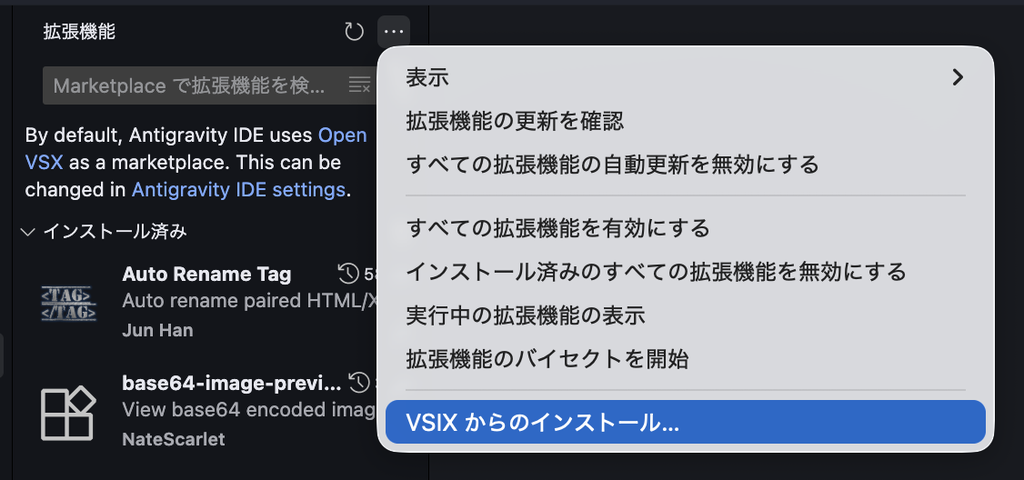

### フォーマッターとツールチェーンの設定

#### swift-format

swift-formatは、Swiftコードの自動整形や構文チェックを行う、Apple公式のツール。Web開発で使うPrettierやESLintのSwift版のようなものである。

Xcodeをインストール済みならすでにインストールされているはずだが、以下のコマンドで確認できる。

```
zsh
```

```bash
xcrun --find swift-format
```

#### ツールチェーン

**ヒントツールチェーンとは**

ツールチェーンとは、人間が書いたソースコードを機械が実行できるプログラムへと変換する開発ツールの集合体のことである。コンパイラやリンカ、デバッガなどがこれにあたる。

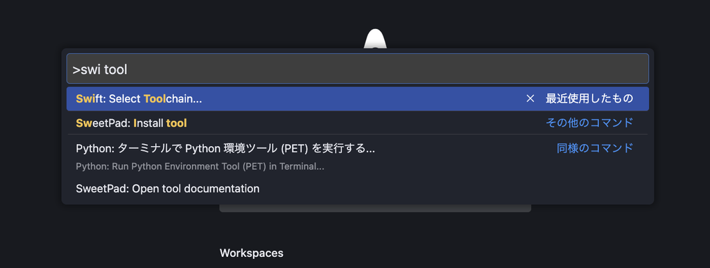

ツールチェーンを選択する画面になるので、`Xcode`を選択する。

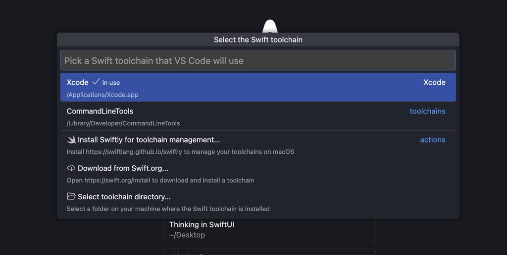

**ノート`Xcode`と`CommandLineTool`の違い**

`Xcode`はシミュレーターや画面のレイアウトツールなど、開発に必要なものが全部詰まってるフルセット。一方で`CommandLineTool`はコンパイラやリンカ、デバッガなどの最低限のツールを提供するようになるセット。

最後に以下のような警告画面が出るので、「Reload Extensions」をクリックして再起動する。

Changing the Swift path requires Visual Studio Code be reloaded.

[^1]: どうりでApp Storeで検索しても結果に表示されないわけである。
[^2]: 2026年9月6日時点。
[^3]: 認証情報の確認と高圧縮率により、展開が完了するまで5〜10分程度かかる。
[^4]: 「[Allegedly 40 apps on App Store are infected - kaspersky daily](https://www.kaspersky.com/blog/xcodeghost-compromises-apps-in-app-store/9965/)」より。2026年9月7日閲覧。
[^5]: アセットカタログは、さまざまな画面サイズや解像度ごとの画像、ダークモード用の色設定などを一元管理できるXcodeの便利な機能。